# Generalized Linear Regression Workshop

Xanthe Walker

2025-08-06

## Introduction

In this workshop, we will explore **Generalized Linear Models (GLMs)** — an extension of linear models that allows us to handle non‑normal response variables such as **binary** (presence/absence) and **count** data.

We will use the **Oribatid mite dataset**, which contains:

- 70 observations from moss and mite samples
- Five environmental measurements for each site
- Abundance of *Galumna* sp.

**Main question:**  
Can the abundance or occurrence of *Galumna* sp. be predicted by environmental features such as water content and topographic position?

We will fit and interpret three types of GLMs:

1. **Logistic regression** for presence/absence (binary) data
2. **Poisson regression** for count data
3. **Quasi‑Poisson regression** for overdispersed count data

Along the way, we will cover **model diagnostics**, **interpretation of coefficients**, and **visualization of predictions**.

### Load and Inspect the Data

We begin by loading the Oribatid mite dataset and examining its structure to confirm variable types and ensure the data is ready for analysis.

```r
mites <- read.csv("../../Data files/mites.csv", stringsAsFactors = TRUE)

# Inspect first rows and structure
head(mites)
```

```
##   Galumna pa totalabund        prop SubsDens WatrCont Substrate Shrub    Topo
## 1       8  1        140 0.057142857    39.18   350.15   Sphagn1   Few Hummock
## 2       3  1        268 0.011194030    54.99   434.81    Litter   Few Hummock
## 3       1  1        186 0.005376344    46.07   371.72 Interface   Few Hummock
## 4       1  1        286 0.003496503    48.19   360.50   Sphagn1   Few Hummock
## 5       2  1        199 0.010050251    23.55   204.13   Sphagn1   Few Hummock
## 6       1  1        209 0.004784689    57.32   311.55   Sphagn1   Few Hummock
```

```r
str(mites)
```

```
## 'data.frame':    70 obs. of  9 variables:
##  $ Galumna   : int  8 3 1 1 2 1 1 1 2 5 ...
##  $ pa        : int  1 1 1 1 1 1 1 1 1 1 ...
##  $ totalabund: int  140 268 186 286 199 209 162 126 123 166 ...
##  $ prop      : num  0.05714 0.01119 0.00538 0.0035 0.01005 ...
##  $ SubsDens  : num  39.2 55 46.1 48.2 23.6 ...
##  $ WatrCont  : num  350 435 372 360 204 ...
##  $ Substrate : Factor w/ 7 levels "Barepeat","Interface",..: 4 3 2 4 4 4 4 2 3 4 ...
##  $ Shrub     : Factor w/ 3 levels "Few","Many","None": 1 1 1 1 1 1 1 2 2 2 ...
##  $ Topo      : Factor w/ 2 levels "Blanket","Hummock": 2 2 2 2 2 2 2 1 1 2 ...
```

### Explore the Data

We will start by plotting:

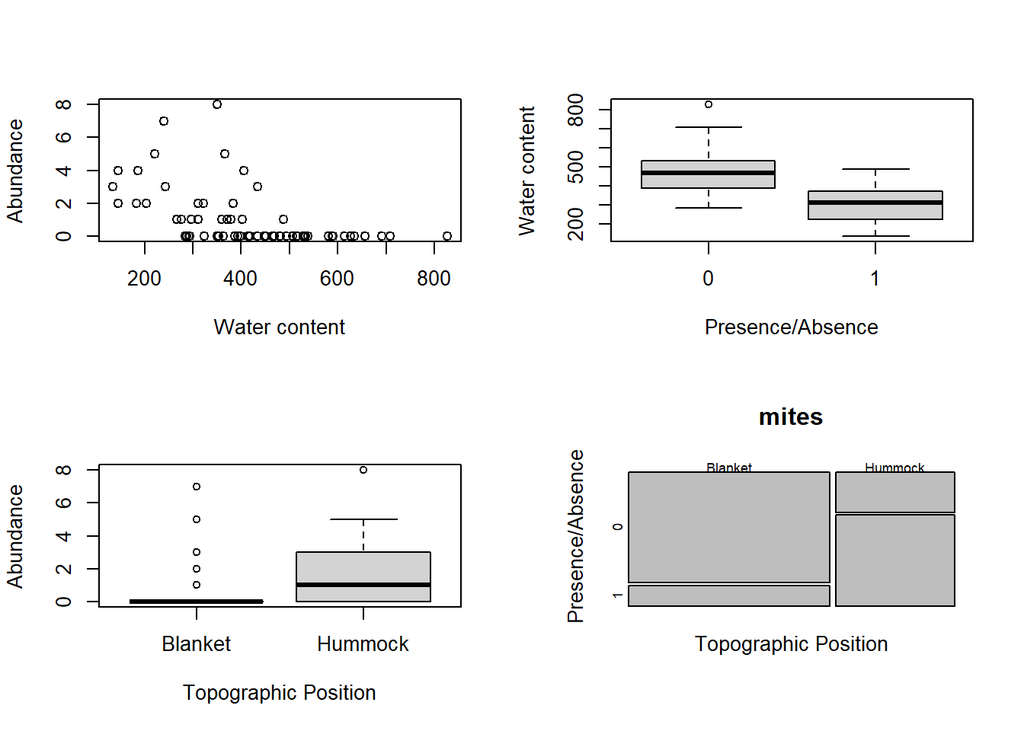

```r
par(mfrow=c(2,2))

# Abundance vs water content
plot(Galumna ~ WatrCont, data = mites,
     xlab = 'Water content', ylab = 'Abundance')

# Water content vs presence/absence
boxplot(WatrCont ~ pa, data = mites,
        xlab='Presence/Absence', ylab = 'Water content')

# Abundance vs topographic position
boxplot(Galumna ~ Topo, data = mites,
        xlab = 'Topographic Position', ylab = 'Abundance')

# Presence/absence vs topographic position
mosaicplot(Topo ~ pa, data = mites,
           ylab='Presence/Absence', xlab = 'Topographic Position')
```

- **Top-left**: Abundance vs. water content
- **Top-right**: Water content vs. presence/absence (boxplot)
- **Bottom-left**: Abundance vs. topographic position
- **Bottom-right**: Presence/absence vs. topographic position (mosaic plot)

*Observation*: Abundance does not appear normally distributed, and presence/absence is a binary variable — a standard linear model is unlikely to be appropriate.

### Linear model: Presence/Absence

Although the presence/absence variable (pa) is binary (0/1), we could still fit a linear model and treat the binary outcome as continuous.

Let’s fit the linear model and check the residual diagnostics:

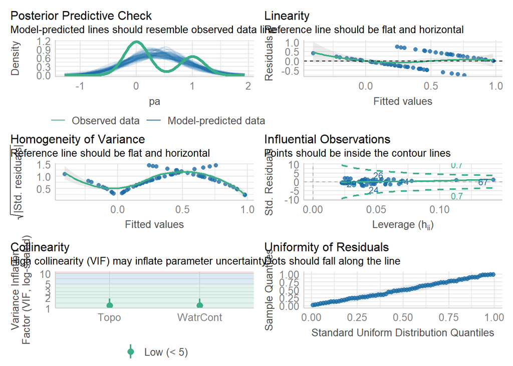

```r
lm.pa <- lm(pa ~ WatrCont+Topo, data = mites)
check_model(lm.pa, residual_type = "simulated")
```

*Observation*: The residual plots confirm poor fit — residuals are not normally distributed, and variance changes with fitted values.

This violates the assumptions of linear regression, making a GLM with a binomial error distribution more appropriate.

### Logistic Regression: Presence/Absence

Logistic regression models the log-odds of the response variable as a linear function of the predictors.

In this section we will:

- Fit a **binomial GLM** with a logit link to model presence/absence of *Galumna* sp.
- Examine model coefficients and convert them to odds ratios and probabilities for interpretation.
- Assess model fit using pseudo-R² and diagnostic checks.
- Visualize predicted probabilities for continuous and categorical predictors.

```r
# Fit logistic regression
logit.reg <- glm(pa ~ WatrCont + Topo,
                 data = mites,
                 family = binomial(link = "logit"))

# Model summary
summary(logit.reg)
```

```
##
## Call:
## glm(formula = pa ~ WatrCont + Topo, family = binomial(link = "logit"),
##     data = mites)
##
## Coefficients:
##              Estimate Std. Error z value Pr(>|z|)
## (Intercept)  4.464402   1.670622   2.672 0.007533 **
## WatrCont    -0.015813   0.004535  -3.487 0.000489 ***
## TopoHummock  2.090757   0.735348   2.843 0.004466 **
## ---
## Signif. codes:  0 '***' 0.001 '**' 0.01 '*' 0.05 '.' 0.1 ' ' 1
##
## (Dispersion parameter for binomial family taken to be 1)
##
##     Null deviance: 91.246  on 69  degrees of freedom
## Residual deviance: 48.762  on 67  degrees of freedom
## AIC: 54.762
##
## Number of Fisher Scoring iterations: 6
```

#### Coefficients:

- The intercept is the log-odds of the outcome when all predictors are at 0 or at their reference level.
- The regression coefficient is the log of the odds ratio comparing individuals who differ in that predictor by one unit, holding the other predictors fixed.

#### From log-odds to odds

Use the exponential function (e^β) to convert log-odds to odds.

```r
exp(logit.reg$coefficient[1])
```

```
## (Intercept)
##    86.86907
```

```r
# Odds ratios with 95% confidence intervals
exp(confint.default(logit.reg))
```

```
##                 2.5 %       97.5 %
## (Intercept) 3.2872196 2295.6283716
## WatrCont    0.9756014    0.9930999
## TopoHummock 1.9145842   34.1927143
```

- **Odds ratio > 1**: predictor increases the odds of presence
- **Odds ratio < 1**: predictor decreases the odds of presence

The CI helps determine if the odds ratio is significantly different from 1. If 1 falls inside the CI → no significant effect.

#### From odds to probabilities

Converting odds to probabilities can aid interpretation for a non-technical audience

If **odds > 1**:

`p = odds / (odds + 1) * 100`

→ gives the probability of the event.

If **odds < 1**:

`p = (1 / odds - 1) * 100`

→ tells how much less likely the event is to occur.

```r
odd.water=exp(logit.reg$coefficient[2])
prob.water=((1/odd.water)-1)*100
prob.water
```

```
## WatrCont
## 1.593823
```

```r
odd.top=exp(logit.reg$coefficient[3])
prob.top=odd.top/(1+odd.top)
prob.top
```

```
## TopoHummock
##   0.8900015
```

Example interpretation:

For a one‑unit increase in WatrCont, the odds of mite presence are estimated at 0.984. Because this is < 1, higher water content is associated with lower odds of presence. Inverting gives 1/0.984 = 1.0159, meaning a 1‑unit increase decreases the likelihood of observing Galumna sp. by 1.59%.

For Topo (Hummock vs Blanket), the odds are 8.09, meaning the probability of observing Galumna sp. is much higher on hummocks than blankets.

#### Null and Residual Deviance

- *Null deviance*: Fit of a model with only the intercept — smaller is better.
- *Residual deviance*: Fit of the model with predictors — smaller is better.

The difference between null and residual deviance can be used to calculate a pseudo-R².

```r
# Pseudo-R²
r2(logit.reg)
```

```
## # R2 for Logistic Regression
##   Tjur's R2: 0.511
```

```r
r2_mcfadden(logit.reg)
```

```
## # R2 for Generalized Linear Regression
##        R2: 0.466
##   adj. R2: 0.444
```

```r
# Manual calculation
(null_dev <- logit.reg$null.deviance)
```

```
## [1] 91.24592
```

```r
(resid_dev <- logit.reg$deviance)
```

```
## [1] 48.7624
```

```r
pseudo_R2 <- (null_dev - resid_dev) / null_dev
pseudo_R2
```

```
## [1] 0.4655937
```

In our case: 0.466 → model explains ~46.6% of the variability. McFadden (1977) suggests values of 0.2–0.4 indicate excellent fit for logistic regression.

Note: Pseudo‑R² should not be interpreted exactly like R² in linear models. There are many versions, and no universal agreement on which is “best.”

#### Model assumptions

It’s trickier to check GLM assumptions than linear models because residuals are not expected to behave normally. The expected distribution of residuals changes with fitted values.

*Deviance residuals*:

- Account for the likelihood function and distribution of the response.
- Show how much each point contributes to the model deviance.
- Should be symmetrically distributed around zero for a good fit.
- Large absolute values indicate observations poorly fitted by the model.

*Plots to examine*:

- Deviance residuals vs fitted values
- Deviance residuals vs each predictor (in and out of the model)
- Deviance residuals vs time
- Deviance residuals vs spatial coordinates (if relevant)

However, even when correctly specified, deviance residuals can appear heteroscedastic or non-normal, so interpret with caution.

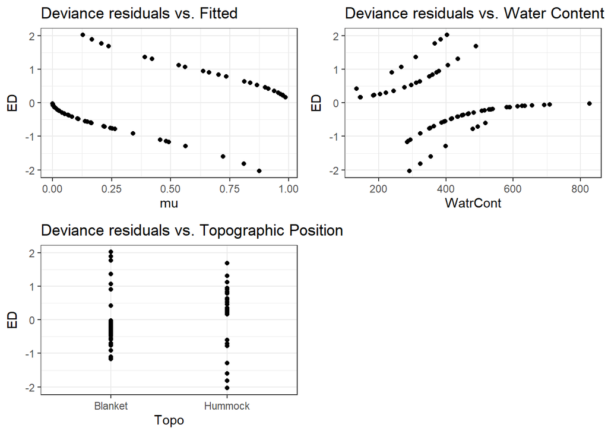

```r
ED <- resid(logit.reg, type = "deviance")
mu <- predict(logit.reg, type = "response")

mites2 <- cbind(mites, ED, mu)

g1 <- ggplot(mites2, aes(x = mu, y = ED)) + geom_point() +
  ggtitle("Deviance residuals vs. Fitted") + theme_bw()

g2 <- ggplot(mites2, aes(x = WatrCont, y = ED)) + geom_point() +
  ggtitle("Deviance residuals vs. Water Content") + theme_bw()

g3 <- ggplot(mites2, aes(x = Topo, y = ED)) + geom_point() +
  ggtitle("Deviance residuals vs. Topographic Position") + theme_bw()

ggpubr::ggarrange(g1, g2, g3)
```

#### Simulated residuals with DHARMa:

These provide a better visual diagnostic for GLMs, as they compare simulated residuals to the observed distribution.

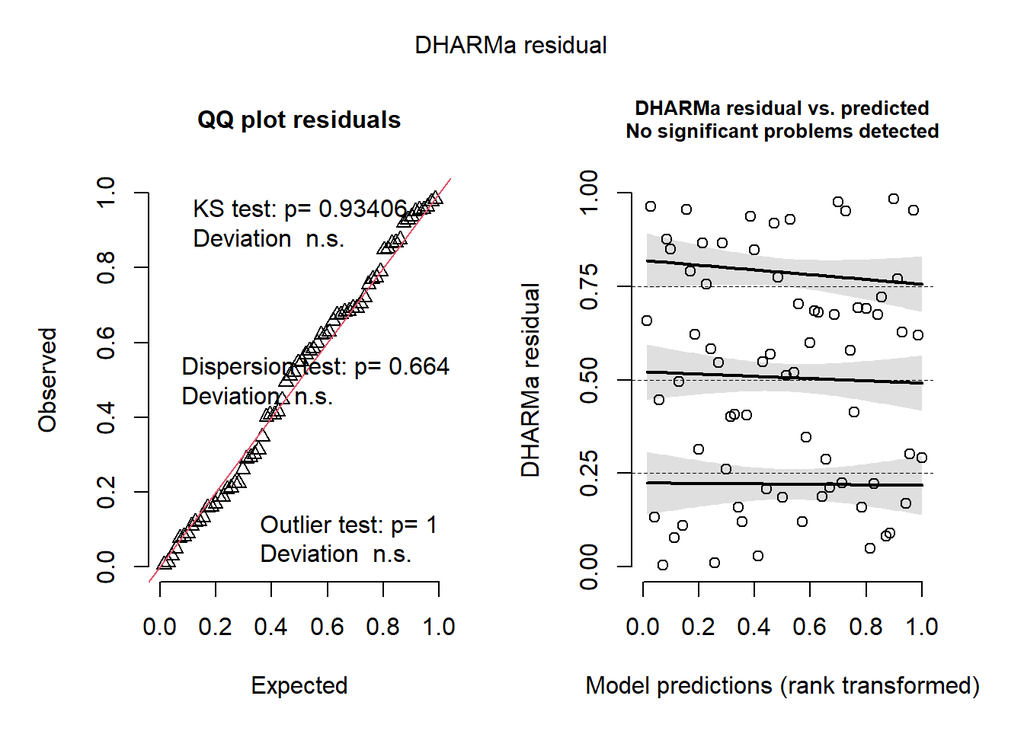

```r
simulationOutput <- simulateResiduals(logit.reg)
plot(simulationOutput)
```

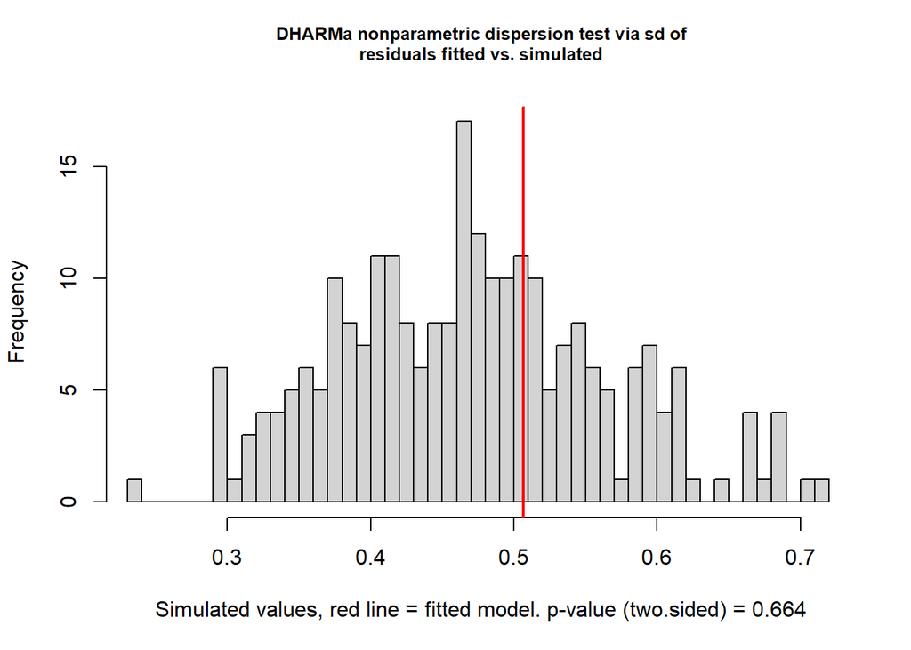

```
##
##  DHARMa nonparametric dispersion test via sd of residuals fitted vs.
##  simulated
##
## data:  simulationOutput
## dispersion = 1.0781, p-value = 0.664
## alternative hypothesis: two.sided
```

```r
testDispersion(logit.reg)
```

### Visualizing Predictions

We can visualize model predictions as:

- Logistic curves for continuous predictors (e.g., water content)
- Estimated probabilities with confidence intervals for categorical predictors (e.g., topographic position)

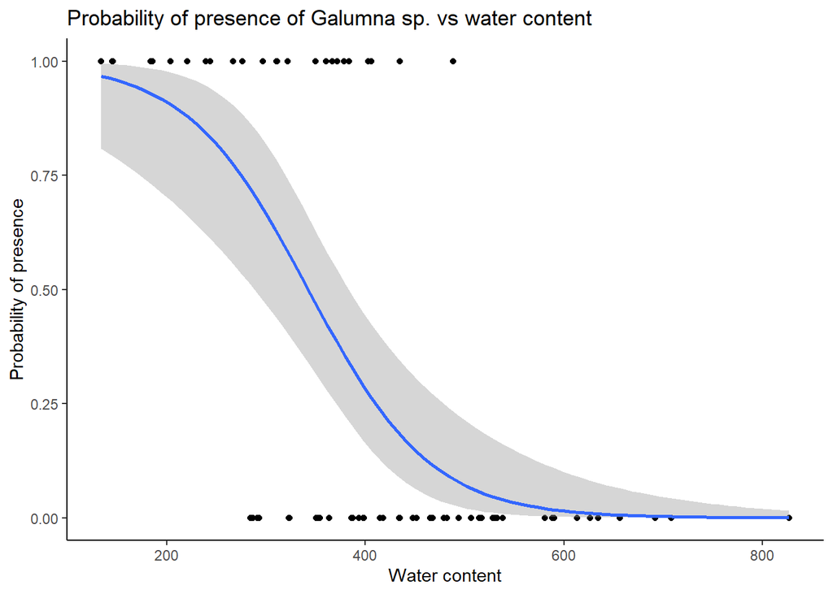

```r
# Logistic curve for water content
ggplot(mites, aes(x = WatrCont, y = pa)) +
  geom_point() +
  stat_smooth(method = "glm", method.args = list(family=binomial), se = TRUE) +
  xlab("Water content") +
  ylab("Probability of presence") +
  ggtitle("Probability of presence of Galumna sp. vs water content") +
  theme_classic()
```

```
## Data points may overlap. Use the `jitter` argument to add some amount of
##   random variation to the location of data points and avoid overplotting.
```

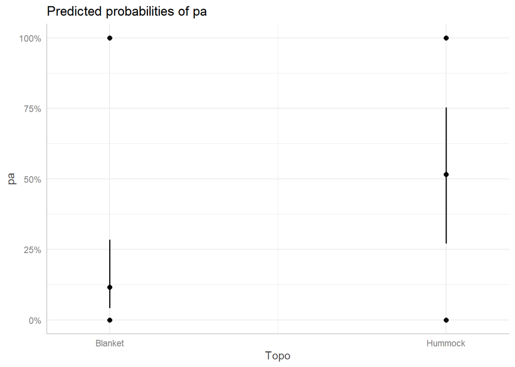

```r
# Predictions for Topo
y <- ggpredict(logit.reg, terms = c("Topo"))
plot(y, show_data = TRUE)
```

## Poisson Regression: Abundance

Poisson regression is used for modeling counts, assuming the variance is equal to the mean.

In this section we will:

- Fit a **Poisson GLM** to model abundance of *Galumna* sp.
- Check for **overdispersion** using diagnostic tools
- Assess model residuals for patterns or violations of assumptions

```r
glm.p <- glm(Galumna ~ WatrCont + Topo, data = mites, family = poisson)

# Summary
summary(glm.p)
```

```
##
## Call:
## glm(formula = Galumna ~ WatrCont + Topo, family = poisson, data = mites)
##
## Coefficients:
##              Estimate Std. Error z value Pr(>|z|)
## (Intercept)  1.937184   0.449489   4.310 1.63e-05 ***
## WatrCont    -0.006736   0.001146  -5.877 4.17e-09 ***
## TopoHummock  0.615095   0.280823   2.190   0.0285 *
## ---
## Signif. codes:  0 '***' 0.001 '**' 0.01 '*' 0.05 '.' 0.1 ' ' 1
##
## (Dispersion parameter for poisson family taken to be 1)
##
##     Null deviance: 168.25  on 69  degrees of freedom
## Residual deviance: 102.98  on 67  degrees of freedom
## AIC: 176.14
##
## Number of Fisher Scoring iterations: 6
```

The summary of a Poisson GLM looks very similar to linear regression output, but the parameters are on the log scale. To make them more interpretable, we can translate them to Incident Rate Ratios (IRRs) by exponentiating the coefficients. This is the default in sjPlot::tab_model().

```r
# Calculate IRRs
exp(coef(glm.p))
```

```
## (Intercept)    WatrCont TopoHummock
##   6.9391855   0.9932866   1.8498324
```

```r
# Display IRRs with CIs
sjPlot::tab_model(glm.p, transform = "exp")
```

|  | Galumna |  |  |
| --- | --- | --- | --- |
| Predictors | Incidence Rate Ratios | CI | p |
| (Intercept) | 6.94 | 2.80 – 16.33 | **<0.001** |
| WatrCont | 0.99 | 0.99 – 1.00 | **<0.001** |
| Topo [Hummock] | 1.85 | 1.08 – 3.27 | **0.029** |
| Observations | 70 |  |  |
| R<sup>2</sup> Nagelkerke | 0.667 |  |  |

*Definition*: The IRR represents the multiplicative change in the rate (or incidence) of the outcome variable associated with a one-unit increase in the predictor variable, holding all other predictors constant.

- IRR > 1 → positive association (increases the rate)
- IRR < 1 → negative association (decreases the rate)

*Examples from our model*:

- Intercept IRR (6.94): The baseline abundance when all predictors are at their reference levels is about 6.94.
- Water Content IRR (0.99): Each 1-unit increase in water content decreases the abundance rate by a factor of 0.99 (~1% decrease).
- Topography (Hummock) IRR (1.85): Abundance is 1.85× higher on hummocks than on blankets, holding water content constant.

### Assessing Dispersion in Poisson Models

In a Poisson GLM, the variance is assumed to equal the mean. We check this by comparing the residual deviance to the residual degrees of freedom:

- If residual deviance ≈ residual df → dispersion parameter ≈ 1 → good fit.
- If residual deviance >> residual df → overdispersion (extra variability not explained by the model).

```r
dispersion <- deviance(glm.p) / df.residual(glm.p)
dispersion
```

```
## [1] 1.537046
```

```r
# Check overdispersion
check_overdispersion(glm.p)
```

```
## # Overdispersion test
##
##        dispersion ratio =   2.197
##   Pearson's Chi-Squared = 147.203
##                 p-value = < 0.001
```

```
## Overdispersion detected.
```

Guidelines (Zuur et al., 2009):

- ~1 → no overdispersion (assumption met)
- 1.5–15 → moderate overdispersion → consider quasi‑Poisson or negative binomial
- 15–>20 → large overdispersion → Poisson likely inappropriate
- Small deviations (<1.5) may be tolerable if sample size is large and fit is reasonable.
- Always consider the research context and nature of the data.

## Quasi-Poisson Regression

If overdispersion is present, a **quasi-Poisson model** can be used to relax the assumption that the variance equals the mean.

We will:

- Fit a quasi-Poisson GLM to the same abundance data
- Translate coefficients to Incident Rate Ratios (IRRs) for interpretation.
- Assess dispersion parameters
- Generate and plot predicted values for each predictor

```r
# Fit quasi-Poisson model
glm.qp <- glm(Galumna ~ WatrCont + Topo, data = mites, family = quasipoisson)

# Summary
summary(glm.qp)
```

```
##
## Call:
## glm(formula = Galumna ~ WatrCont + Topo, family = quasipoisson,
##     data = mites)
##
## Coefficients:
##              Estimate Std. Error t value Pr(>|t|)
## (Intercept)  1.937184   0.666256   2.908 0.004935 **
## WatrCont    -0.006736   0.001699  -3.965 0.000181 ***
## TopoHummock  0.615095   0.416250   1.478 0.144172
## ---
## Signif. codes:  0 '***' 0.001 '**' 0.01 '*' 0.05 '.' 0.1 ' ' 1
##
## (Dispersion parameter for quasipoisson family taken to be 2.197067)
##
##     Null deviance: 168.25  on 69  degrees of freedom
## Residual deviance: 102.98  on 67  degrees of freedom
## AIC: NA
##
## Number of Fisher Scoring iterations: 6
```

#### Interpreting Coefficients

As with the Poisson model, coefficients are on the log scale and can be exponentiated to obtain IRRs:

```r
# Calculate IRRs
exp(coef(glm.qp))
```

```
## (Intercept)    WatrCont TopoHummock
##   6.9391855   0.9932866   1.8498324
```

```r
# IRRs with confidence intervals
sjPlot::tab_model(glm.qp, transform = "exp")
```

|  | Galumna |  |  |
| --- | --- | --- | --- |
| Predictors | Incidence Rate Ratios | CI | p |
| (Intercept) | 6.94 | 1.77 – 24.23 | **0.004** |
| WatrCont | 0.99 | 0.99 – 1.00 | **<0.001** |
| Topo [Hummock] | 1.85 | 0.84 – 4.37 | 0.139 |
| Observations | 70 |  |  |
| R<sup>2</sup> Nagelkerke | 0.667 |  |  |

#### Dispersion Parameter

The quasi‑Poisson model estimates the dispersion parameter directly from the data:

```r
dispersion_qp <- summary(glm.qp)$dispersion
dispersion_qp
```

```
## [1] 2.197067
```

Dispersion ≈ 1 → no overdispersion detected.

Dispersion > 1 → overdispersion accounted for by the model.

This model corrects the standard errors and p‑values for overdispersion, making them more reliable than those from the Poisson model when variance > mean.

## Visualize Predictions – Quasi‑Poisson Model

```r
# Predictions for continuous predictor: Water content

y_wc <- ggpredict(glm.qp, terms = "WatrCont")
p_wc <- plot(y_wc, rawdata = TRUE) +
  labs(x = "Water content",
       y = "Predicted abundance",
       title = "Predicted abundance of Galumna sp. vs Water content") +
  theme_classic()
```

```
## Data points may overlap. Use the `jitter` argument to add some amount of
##   random variation to the location of data points and avoid overplotting.
```

```r
# Predictions for categorical predictor: Topography
y_topo <- ggpredict(glm.qp, terms = "Topo")
p_topo <- plot(y_topo, rawdata = TRUE) +
  labs(x = "Topographic Position",
       y = "Predicted abundance",
       title = "Predicted abundance of Galumna sp. by Topographic Position") +
  theme_classic()
```

```
## Data points may overlap. Use the `jitter` argument to add some amount of
##   random variation to the location of data points and avoid overplotting.
```

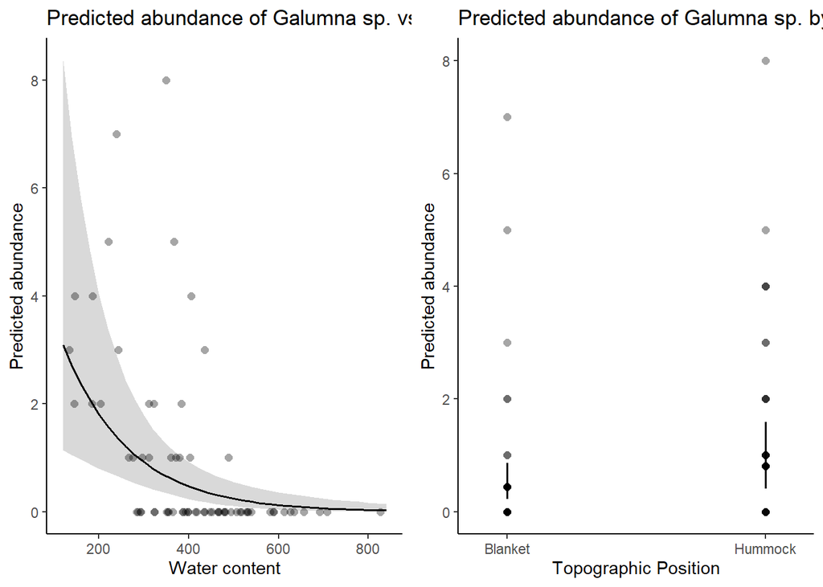

```r
# Arrange side-by-side
ggpubr::ggarrange(p_wc, p_topo, ncol = 2)
```

*Note on Negative Binomial models*: If overdispersion is high and not well addressed by a quasi‑Poisson model, a Negative Binomial model (glm.nb() from the MASS package) can be used. This model estimates an additional dispersion parameter and can be compared with other models using AIC.

# Exercises

## Butterfly color

Mayekar et al (2017) studied some potential determinants of color (green vs brown) of a tropical butterfly species. A laboratory population was established, and newly hatched larvae were placed in a growth chamber set at either 60% or 85% relative humidity. Resulting pupae were recorded for colour, time to pupation, pupal weight and sex.

We will use their data to model green vs brown pupae against the two continuous predictors (time to pupation, pupal weight) and the one categorical predictor (sex). We will only use data from the low humidity treatment as brown pupae were very uncommon at high humidity.

Mayekar, H. V. & Kodandaramaiah, U. (2017). Pupal colour plasticity in a tropical butterfly, *Mycalesis mineus* (Nymphalidae: Satyrinae). *PLoS One*, 12, e0171482.

The paper is [here](https://doi.org/10.1371/journal.pone.0171482), and Figure 1 is an excellent image of the divergent colour phenotypes.

**Coding notes:** - `colnum`: binary variable coded as 0 = brown pupae, 1 = green pupae - `sex`: categorical factor with two levels (male/female) - `timepup`, `weight`: continuous predictors - `rh`: relative humidity treatment (factor with “low” and “high”)

1. Import mayekar data file (mayekar.csv) and examine it.
2. Examine the levels of the ‘rh; relative humidity’ variable. Create subset of the low-humidity treatment (rh=low)
3. Make simple plots for cont. predictors of timepup and weight
4. Fit full glm with 3 way-interaction.
5. Check for collinearity
6. Try centering continuous predictors to reduce collinearity
7. Fit full model with centered predictors
8. Determine if interactions are necessary and create a final reduced model.
9. Check assumptions for the final model. In other words, get and plot residuals - focus on deviance residuals plot. You can also use simulated residuals in the DHARMa package.
10. Get odds ratio with CI and interpret the results.
11. Plot the final model fit

## Post-fire ecology of wiregrass

Fill et al (2021) studied the effect of duff (leaf litter) on the post-fire ecology of wiregrass (*Aristida beyrichiana*) in a section of pine savanna. They sampled 99 plants in an area of 0.1 km<sup>2</sup>, recorded plant basal area and allocated each plant to one of three treatments: high duff, low duff, low duff with added pine cones. They then burnt the area and five months later, counted the number of culms on each plant. We will model numbers of culms per plant against basal area and duff treatment using each plant as the unit of analysis.

The paper is [here](https://doi.org/10.1371/journal.pone.0247159) and Figure 1 has relevant photos.

**Coding notes:** - `culm`: integer count of culms - `treatment`: categorical factor with three levels (high duff, low duff, low duff + cones) - `basalarea`: continuous predictor

1. Read and examine the data (fill.csv)
2. Check culm distribution with histogram
3. Make a boxplot of culm counts per treatment
4. Fit poisson glm with basalarea, treatment, and their interaction as predictors
5. Check deviance residuals and collinearity
6. Check overdispersion.
7. Test the significance of fixed effects. In other words, compare the full model to a model without an interaction. Is the interaction significant?
8. Fit a neg binomial glm.
9. Check model diagnostics and dispersion statistics. Is this model a better fit than the poisson?
10. Determine the significance of fixed effects. Are you conclusion different or the same to the poisson glm?